# tallbuildings

Issy Belzil & Mikaela Murgoitio

2017-10-03

### Setting up:

```r
library(readxl)
tallbuild=read_excel("tallestbuildings.xlsx")
library(ggplot2)
library(dplyr)
library(tidyr)
```

### 1: Please display how many buildings are there in each city represented in that dataset. An arrangement in either an ascending or a descending order of number of buildings is always helpful to an eye.

```r
summary(tallbuild)
```

```
##       Rank        Building Name          City             Height (m)
##  Min.   :  1.00   Length:100         Length:100         Min.   :301.8
##  1st Qu.: 25.75   Class :character   Class :character   1st Qu.:308.6
##  Median : 50.50   Mode  :character   Mode  :character   Median :329.3
##  Mean   : 50.45                                         Mean   :358.6
##  3rd Qu.: 75.25                                         3rd Qu.:380.6
##  Max.   :100.00                                         Max.   :828.0
##   Height (ft)       Floors         Completed      Material
##  Min.   : 990   Min.   : 41.00   Min.   :1930   Length:100
##  1st Qu.:1012   1st Qu.: 68.00   1st Qu.:2002   Class :character
##  Median :1080   Median : 73.00   Median :2011   Mode  :character
##  Mean   :1177   Mean   : 77.02   Mean   :2005
##  3rd Qu.:1248   3rd Qu.: 85.00   3rd Qu.:2014
##  Max.   :2717   Max.   :163.00   Max.   :2016
##      Use
##  Length:100
##  Class :character
##  Mode  :character
##
##
##
```

```r
tallbuild %>% group_by(City) %>% summarise(cnt = n()) %>% arrange(desc(cnt))
```

```
## # A tibble: 38 x 2
##                  City   cnt
##                 <chr> <int>
##  1         Dubai (AE)    18
##  2 New York City (US)     7
##  3       Chicago (US)     6
##  4     Guangzhou (CN)     6
##  5     Hong Kong (CN)     6
##  6     Abu Dhabi (AE)     4
##  7        Moscow (RU)     4
##  8      Shanghai (CN)     4
##  9      Shenzhen (CN)     4
## 10  Kuala Lumpur (MY)     3
## # ... with 28 more rows
```

### 2: Please plot different cities in order of the mean height of buildings in a city.

```r
names(tallbuild)[names(tallbuild) == 'Height (ft)'] <- 'Heightft'
```

```r
tallb=tallbuild%>%group_by(City)%>%summarize(meanb =mean(Heightft))
#%>% arrange(desc(mean))
```

```r
str(tallb)
```

```
## Classes 'tbl_df', 'tbl' and 'data.frame':    38 obs. of  2 variables:
##  $ City : chr  "Abu Dhabi (AE)" "Atlanta (US)" "Bangkok (TH)" "Beijing (CN)" ...
##  $ meanb: num  1110 1023 1014 1083 1184 ...
```

### 2:

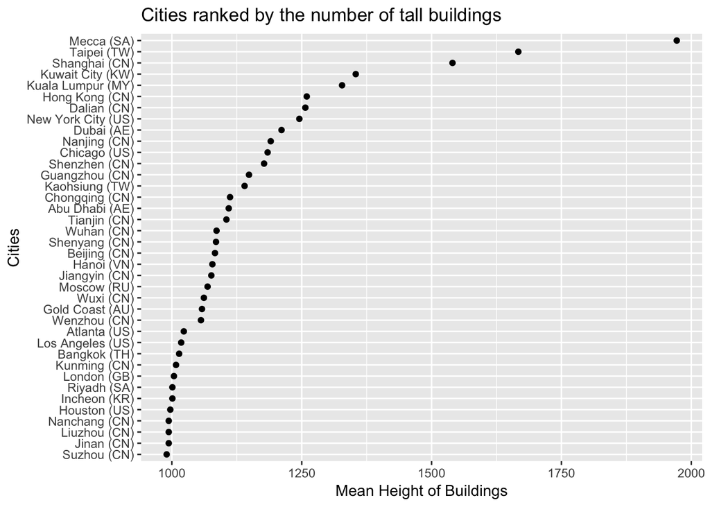

```r
ggplot(data = tallb, aes(x=reorder(City,meanb),  y=meanb)) + geom_point(stat="identity", fill="blue")+coord_flip() +labs(list(title = "Cities ranked by the number of tall buildings", x="Cities", y="Mean Height of Buildings"))
```

```r
library(countrycode)
```

### 3: 3 and 4. Please redo 1 and 2 using the country information that is given. (Note that the country variable is present with the city variable. Perhaps a split of that variable is necessary.) You may want to check out the countrycode package to get the full names of different countries instead of relying on the cryptic country codes that are present in that dataset.

?countrycode_data

```r
tallb2=tallbuild %>% separate(City, c("City", "CountryCode"), sep="[:punct:]")
str(tallb2)
```

```
## Classes 'tbl_df', 'tbl' and 'data.frame':    100 obs. of  10 variables:
##  $ Rank         : num  1 2 3 4 5 6 7 8 8 10 ...
##  $ Building Name: chr  "Burj Khalifa" "Shanghai Tower" "Makkah Royal Clock Tower" "One World Trade Center" ...
##  $ City         : chr  "Dubai " "Shanghai " "Mecca " "New York City " ...
##  $ CountryCode  : chr  "AE" "CN" "SA" "US" ...
##  $ Height (m)   : num  828 632 601 541 508 ...
##  $ Heightft     : num  2717 2073 1972 1776 1667 ...
##  $ Floors       : num  163 128 120 94 101 101 108 88 88 66 ...
##  $ Completed    : num  2010 2015 2012 2014 2004 ...
##  $ Material     : chr  "steel/concrete" "composite" "steel/concrete" "composite" ...
##  $ Use          : chr  "office / residential / hotel" "hotel / office" "other / hotel" "office" ...
```

> install.packages(“countrycode”) library(countrycode)

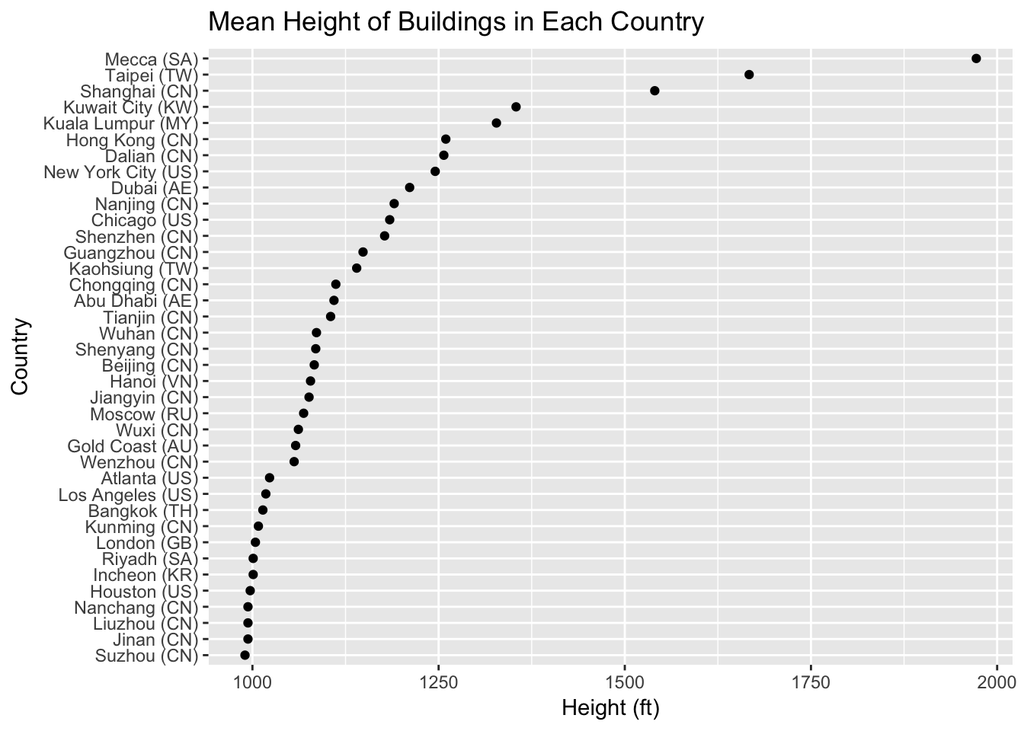

```r
ggplot(data = tallb, aes(x=reorder(City,meanb),  y=meanb)) + geom_point(stat="identity", fill="blue")+coord_flip() +labs(list(title = "Mean Height of Buildings in Each Country", x = "Country", y = "Height (ft)"))
```

```r
tallb2$Country=countrycode(tallb2$CountryCode, "iso2c", "country.name", warn = TRUE, custom_dict = NULL,
  custom_match =NULL, origin_regex = FALSE)
```

### 3:

```r
str(tallb2)
```

```
## Classes 'tbl_df', 'tbl' and 'data.frame':    100 obs. of  11 variables:
##  $ Rank         : num  1 2 3 4 5 6 7 8 8 10 ...
##  $ Building Name: chr  "Burj Khalifa" "Shanghai Tower" "Makkah Royal Clock Tower" "One World Trade Center" ...
##  $ City         : chr  "Dubai " "Shanghai " "Mecca " "New York City " ...
##  $ CountryCode  : chr  "AE" "CN" "SA" "US" ...
##  $ Height (m)   : num  828 632 601 541 508 ...
##  $ Heightft     : num  2717 2073 1972 1776 1667 ...
##  $ Floors       : num  163 128 120 94 101 101 108 88 88 66 ...
##  $ Completed    : num  2010 2015 2012 2014 2004 ...
##  $ Material     : chr  "steel/concrete" "composite" "steel/concrete" "composite" ...
##  $ Use          : chr  "office / residential / hotel" "hotel / office" "other / hotel" "office" ...
##  $ Country      : chr  "United Arab Emirates" "China" "Saudi Arabia" "United States of America" ...
```

```r
tallb2 %>% group_by(Country) %>% summarise(cnt = n()) %>% arrange(desc(cnt))
```

```
## # A tibble: 13 x 2
##                                                 Country   cnt
##                                                   <chr> <int>
##  1                                                China    42
##  2                                 United Arab Emirates    22
##  3                             United States of America    17
##  4                                   Russian Federation     4
##  5                                             Malaysia     3
##  6                                         Saudi Arabia     3
##  7                            Taiwan, Province of China     2
##  8                                             Thailand     2
##  9                                            Australia     1
## 10                                               Kuwait     1
## 11                                    Republic of Korea     1
## 12 United Kingdom of Great Britain and Northern Ireland     1
## 13                                             Viet Nam     1
```

```r
names(tallb2)[names(tallb2) == 'Height (ft)'] <- 'Heightft'
```

```r
tallb3=tallb2%>%group_by(Country)%>%summarize(meanb =mean(Heightft))
#%>% arrange(desc(mean))
```

```r
str(tallb3)
```

```
## Classes 'tbl_df', 'tbl' and 'data.frame':    13 obs. of  2 variables:
##  $ Country: chr  "Australia" "China" "Kuwait" "Malaysia" ...
##  $ meanb  : num  1058 1167 1354 1328 1001 ...
```

library(ggplot2) library(dplyr) library(tidyr)

### 4:

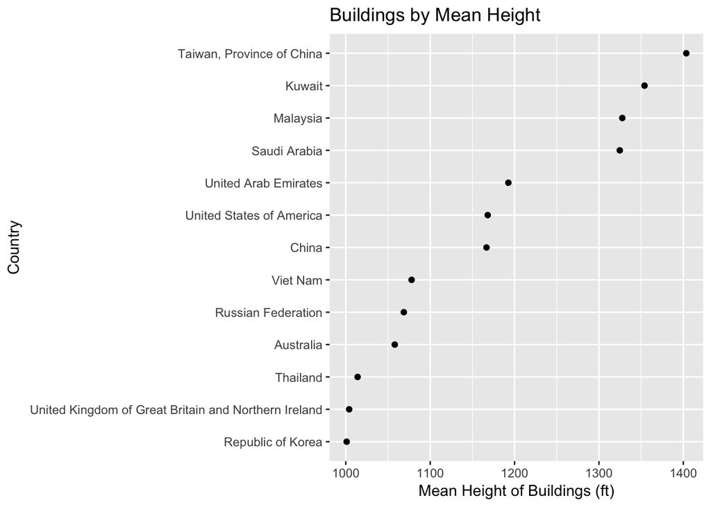

```r
ggplot(data = tallb3 , aes(x=reorder(Country,meanb),  y=meanb)) + geom_point(stat="identity", fill="blue")+coord_flip() + labs(list(title = "Buildings by Mean Height", x = "Country", y = "Mean Height of Buildings (ft)"))
```

### 5: In 4 above, you would’ve plot different countries in order of their mean height of a buildings in a city. If you have not used a bar graph there, please create a bar graph. In this bar graph, please color each bar for a country based on the number of buildings from this dataset that are present in that country.

```r
tallbcount = tallb2 %>% group_by(Country) %>% summarise(Bcount = n(),meanheight =mean(Heightft))
```

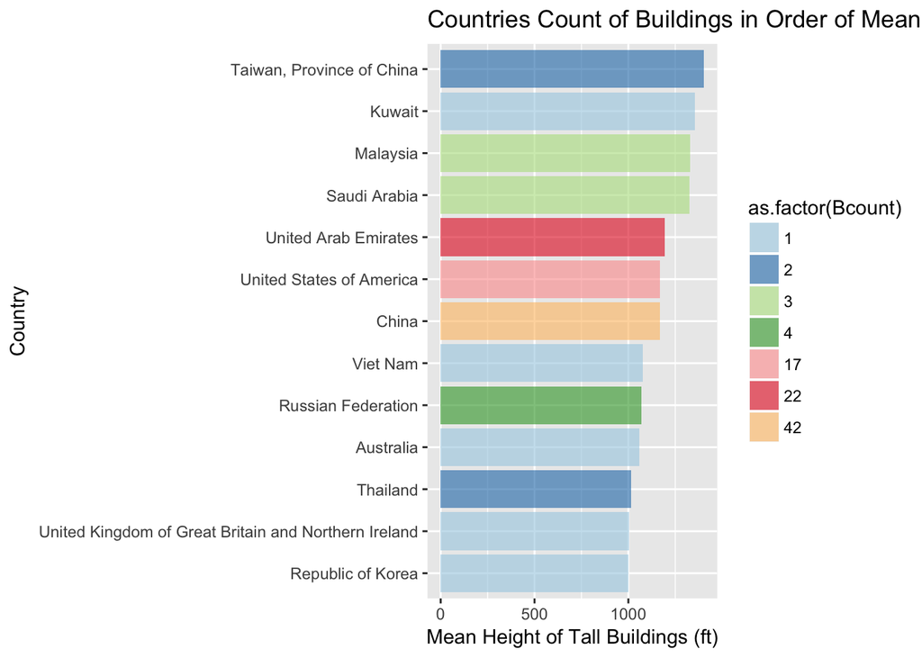

```r
ggplot(data = tallbcount, aes(x=reorder(Country,meanheight),  y=meanheight, fill=as.factor(Bcount))) + geom_bar(stat="identity", alpha=.60)+coord_flip() + scale_fill_brewer(palette="Paired") + labs(list(title = "Countries Count of Buildings in Order of Mean Heights", x = "Country", y = "Mean Height of Tall Buildings (ft)"))
```

### 6: What are the mean heights (in feet) of buildings that are used for diferent purposes. (Here, you will have different purposes in a column and the corresponding mean height in a different column.) In computing this, it is okay to double or triple count a building if it has mutliple uses.

```r
tallbuse = tallbuild %>% group_by(Use) %>% summarise(meanheight =mean(Heightft))
str(tallbuse)
```

```
## Classes 'tbl_df', 'tbl' and 'data.frame':    14 obs. of  2 variables:
##  $ Use       : chr  "hotel" "hotel / office" "hotel / office / retail" "hotel / residential / office" ...
##  $ meanheight: num  1069 1280 1117 1078 1076 ...
```

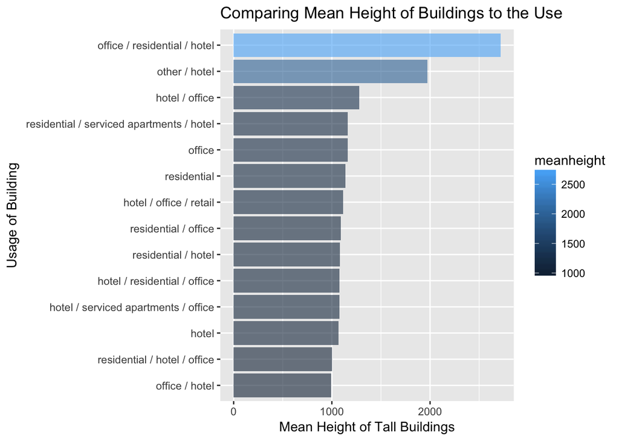

```r
ggplot(data = tallbuse, aes(x=reorder(Use, meanheight),  y=meanheight, fill=meanheight )) + geom_bar(stat="identity", alpha=.60)+coord_flip() + labs(list(title = "Comparing Mean Height of Buildings to the Use", x = "Usage of Building", y = "Mean Height of Tall Buildings"))
```